# MNIST_modeling_anaysis

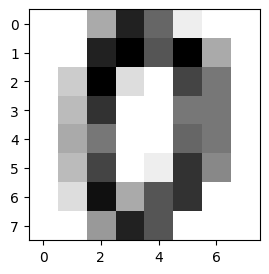

```python
# Code source: Gaël Varoquaux
# Modified for documentation by Jaques Grobler
# License: BSD 3 clause

import matplotlib.pyplot as plt

from sklearn import datasets

# Load the digits dataset
digits = datasets.load_digits()

# Display the last digit
plt.figure(1, figsize=(3, 3))
plt.imshow(digits.images[0], cmap=plt.cm.gray_r, interpolation="nearest")
plt.show()
```

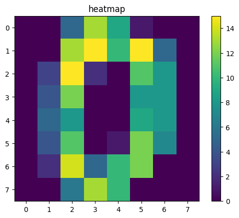

```python
from sklearn import datasets

dataset = datasets.load_digits()
x_data = dataset.data
y_data = dataset.target

import matplotlib.pyplot as plt
import matplotlib as mpl
plt.imshow(dataset.data[0].reshape(8,8))
plt.colorbar()
plt.title('heatmap')
plt.show()
```

```python
print("Number of samples: {}, Number of features: {}".format(digits.data.shape[0], digits.data.shape[1]))
print("Number of classes: {}".format(len(set(digits.target))))
```

```
Number of samples: 1797, Number of features: 64
Number of classes: 10
```

1797개의 숫자 데이터가 있으며 하나의 데이터는 8x8 형태의 행렬로 64개의 픽셀로 이루어짐

```python
digits.images[382]
```

```
array([[ 0.,  0.,  5., 11.,  4.,  1.,  0.,  0.],
       [ 0.,  0., 15., 16., 16., 11.,  0.,  0.],
       [ 0.,  2., 16.,  9.,  2., 12.,  4.,  0.],
       [ 0.,  6., 13.,  0.,  0.,  6.,  6.,  0.],
       [ 0.,  3., 13.,  0.,  0.,  5.,  9.,  0.],
       [ 0.,  3., 16.,  0.,  0.,  6.,  8.,  0.],
       [ 0.,  0., 13., 12.,  8., 16.,  7.,  0.],
       [ 0.,  0.,  4., 13., 12., 10.,  0.,  0.]])
```

```python
#for i in range(1797) :
#print(digits.images[i].max())
```

0은 흰색 ,숫자가 높을수록 진함을 의미 0~16

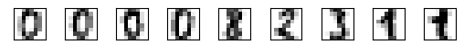

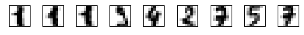

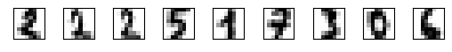

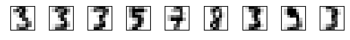

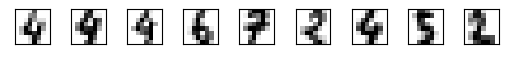

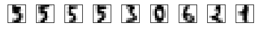

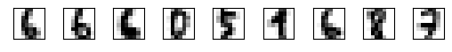

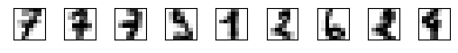

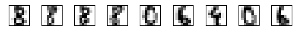

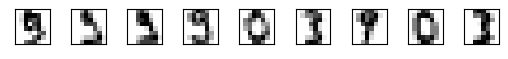

```python
for i in range (10):

    plt.subplot(991)
    plt.imshow(digits.images[i], cmap=plt.cm.gray_r, interpolation="nearest")
    plt.gca().axes.yaxis.set_ticklabels([])
    plt.gca().axes.xaxis.set_ticklabels([])
    ax = plt.gca()
    ax.axes.xaxis.set_visible(False)
    ax.axes.yaxis.set_visible(False)

    plt.subplot(992)
    plt.imshow(digits.images[i+10], cmap=plt.cm.gray_r, interpolation="nearest")
    plt.gca().axes.yaxis.set_ticklabels([])
    plt.gca().axes.xaxis.set_ticklabels([])
    ax = plt.gca()
    ax.axes.xaxis.set_visible(False)
    ax.axes.yaxis.set_visible(False)

    plt.subplot(993)
    plt.imshow(digits.images[i+20], cmap=plt.cm.gray_r, interpolation="nearest")
    plt.gca().axes.yaxis.set_ticklabels([])
    plt.gca().axes.xaxis.set_ticklabels([])
    ax = plt.gca()
    ax.axes.xaxis.set_visible(False)
    ax.axes.yaxis.set_visible(False)

    plt.subplot(994)
    plt.imshow(digits.images[i+30], cmap=plt.cm.gray_r, interpolation="nearest")
    plt.gca().axes.yaxis.set_ticklabels([])
    plt.gca().axes.xaxis.set_ticklabels([])
    ax = plt.gca()
    ax.axes.xaxis.set_visible(False)
    ax.axes.yaxis.set_visible(False)

    plt.subplot(995)
    plt.imshow(digits.images[i+40], cmap=plt.cm.gray_r, interpolation="nearest")
    plt.gca().axes.yaxis.set_ticklabels([])
    plt.gca().axes.xaxis.set_ticklabels([])
    ax = plt.gca()
    ax.axes.xaxis.set_visible(False)
    ax.axes.yaxis.set_visible(False)

    plt.subplot(996)
    plt.imshow(digits.images[i+50], cmap=plt.cm.gray_r, interpolation="nearest")
    plt.gca().axes.yaxis.set_ticklabels([])
    plt.gca().axes.xaxis.set_ticklabels([])
    ax = plt.gca()
    ax.axes.xaxis.set_visible(False)
    ax.axes.yaxis.set_visible(False)

    plt.subplot(997)
    plt.imshow(digits.images[i+60], cmap=plt.cm.gray_r, interpolation="nearest")
    plt.gca().axes.yaxis.set_ticklabels([])
    plt.gca().axes.xaxis.set_ticklabels([])
    ax = plt.gca()
    ax.axes.xaxis.set_visible(False)
    ax.axes.yaxis.set_visible(False)

    plt.subplot(998)
    plt.imshow(digits.images[i+70], cmap=plt.cm.gray_r, interpolation="nearest")
    plt.gca().axes.yaxis.set_ticklabels([])
    plt.gca().axes.xaxis.set_ticklabels([])
    ax = plt.gca()
    ax.axes.xaxis.set_visible(False)
    ax.axes.yaxis.set_visible(False)

    plt.subplot(999)
    plt.imshow(digits.images[i+80], cmap=plt.cm.gray_r, interpolation="nearest")
    plt.gca().axes.yaxis.set_ticklabels([])
    plt.gca().axes.xaxis.set_ticklabels([])
    ax = plt.gca()
    ax.axes.xaxis.set_visible(False)
    ax.axes.yaxis.set_visible(False)

    plt.show()
```

같은 숫자끼리도 필기체가 다름 초반에 반복되는 패턴을 보임

```python
n = 0
for i in range (1797):
    if digits.target[i] == 0:
        n += 1
print('0 :' ,n)

n = 0
for i in range (1797):
    if digits.target[i] == 1:
        n += 1
print('1 :' ,n)

n = 0
for i in range (1797):
    if digits.target[i] == 2:
        n += 1
print('2 :' ,n)

n = 0
for i in range (1797):
    if digits.target[i] == 3:
        n += 1
print('3 :' ,n)

n = 0
for i in range (1797):
    if digits.target[i] == 4:
        n += 1
print('4 :' ,n)

n = 0
for i in range (1797):
    if digits.target[i] == 5:
        n += 1
print('5 :' ,n)

n = 0
for i in range (1797):
    if digits.target[i] == 6:
        n += 1
print('6 :' ,n)

n = 0
for i in range (1797):
    if digits.target[i] == 7:
        n += 1
print('7 :' ,n)

n = 0
for i in range (1797):
    if digits.target[i] == 8:
        n += 1
print('8 :' ,n)

n = 0
for i in range (1797):
    if digits.target[i] == 9:
        n += 1
print('9 :' ,n)
```

```
0 : 178
1 : 182
2 : 177
3 : 183
4 : 181
5 : 182
6 : 181
7 : 179
8 : 174
9 : 180
```

각 카테고리별 개수가 정확히 일치하지는 않지만 훈련하는데 있어서 지장이 클 정도로 클래스 불균형을 보이지는 않음.

데이터 셔플하고 모델링 시작

# 모델링

```python
import time

# 셀의 시작 부분에 다음 코드를 추가
start_time = time.time()


# 끝부분에
end_time = time.time()
elapsed_time = end_time - start_time
print(f"'Logistic Regresstion' Elapsed Time: {elapsed_time:.5f} seconds")
```

```
'Logistic Regresstion' Elapsed Time: 0.00004 seconds
```

# Linear regression

X

# Logistic regression

```python
from sklearn.model_selection import train_test_split
from sklearn.linear_model import LogisticRegression
from sklearn.metrics import accuracy_score
from sklearn import datasets

# Load the digits dataset
digits.data, digits.target = shuffle(digits.data, digits.target, random_state=42)
x_data = digits.data
y_data = digits.target

x_train, x_test, y_train, y_test = train_test_split(x_data, y_data, test_size=0.3, random_state=42)

# Create a logistic regression model (for classification)max_iter=1000
model = LogisticRegression(max_iter=30, multi_class='multinomial', solver='lbfgs')
model.fit(x_train, y_train)

# Make predictions on the training set
y_train_predict = model.predict(x_train)
train_accuracy = accuracy_score(y_train, y_train_predict)
print(f'Training Accuracy: {train_accuracy}')

# Make predictions on the test set
y_test_predict = model.predict(x_test)
test_accuracy = accuracy_score(y_test, y_test_predict)
print(f'Test Accuracy: {test_accuracy}')
```

```
Training Accuracy: 1.0
Test Accuracy: 0.9537037037037037
```

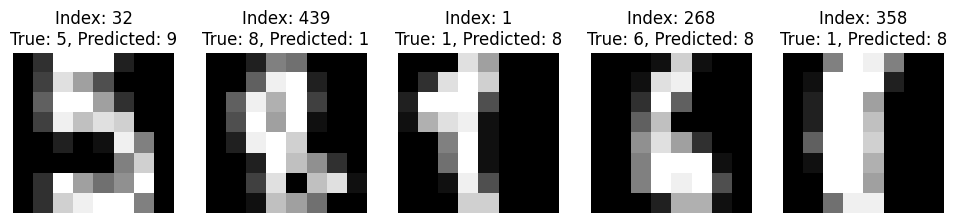

```python
import numpy as np
import matplotlib.pyplot as plt

# Make predictions on the test set
y_test_predict = model.predict(x_test)

# Find indices of misclassified samples
misclassified_indices = np.where(y_test != y_test_predict)[0]

# Select a few random misclassified samples
random_misclassified_indices = np.random.choice(misclassified_indices, size=5, replace=False)

# Plot the misclassified samples with index information
plt.figure(figsize=(12, 4))
for i, idx in enumerate(random_misclassified_indices, 1):
    plt.subplot(1, 5, i)
    plt.imshow(x_test[idx].reshape(8, 8), cmap='gray')
    plt.title(f'Index: {idx}\nTrue: {y_test[idx]}, Predicted: {y_test_predict[idx]}')
    plt.axis('off')

plt.show()
```

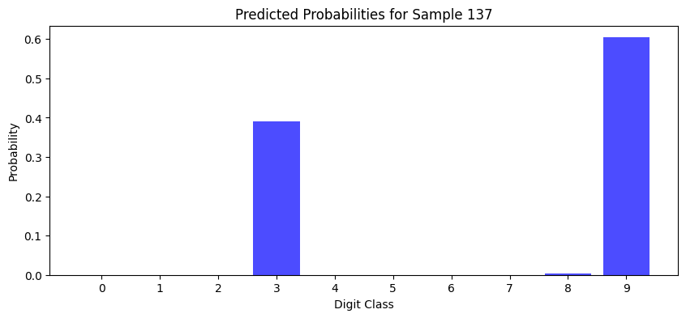

```python
import numpy as np
import matplotlib.pyplot as plt

# Select a random test sample
random_index = np.random.choice(len(x_test))

# Extract features and reshape to match the input image size
sample_features = x_test[137].reshape(1, -1)

# Make predictions for the selected sample
predicted_probabilities = model.predict_proba(sample_features)

# Plot the predicted probabilities
plt.figure(figsize=(10, 4))
plt.bar(range(10), predicted_probabilities[0], color='blue', alpha=0.7)
plt.xticks(range(10), [str(i) for i in range(10)])
plt.title(f'Predicted Probabilities for Sample {137}')
plt.xlabel('Digit Class')
plt.ylabel('Probability')
plt.show()
```

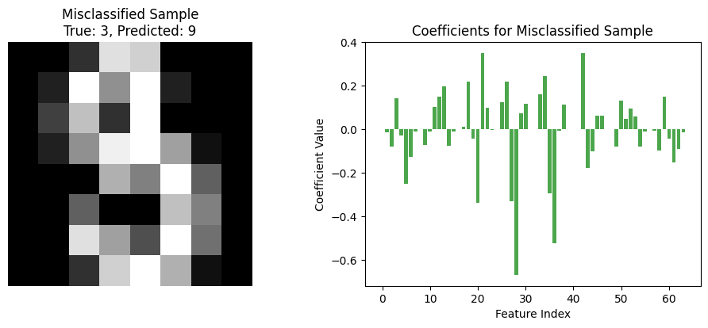

```python
# Select the misclassified sample
misclassified_sample = x_test[137].reshape(1, -1)

# Get the predicted probabilities
predicted_probabilities = model.predict_proba(misclassified_sample)

# Extract the coefficients (weights) for the selected sample
sample_coefficients = model.coef_

# Plot the misclassified sample and its coefficients
plt.figure(figsize=(12, 4))

# Plot the misclassified sample
plt.subplot(1, 2, 1)
plt.imshow(misclassified_sample.reshape(8, 8), cmap='gray')
plt.title(f'Misclassified Sample\nTrue: {y_test[137]}, Predicted: {y_test_predict[137]}')
plt.axis('off')

# Plot the coefficients
plt.subplot(1, 2, 2)
plt.bar(range(64), sample_coefficients[0], color='green', alpha=0.7)
plt.title('Coefficients for Misclassified Sample')
plt.xlabel('Feature Index')
plt.ylabel('Coefficient Value')

plt.show()
```

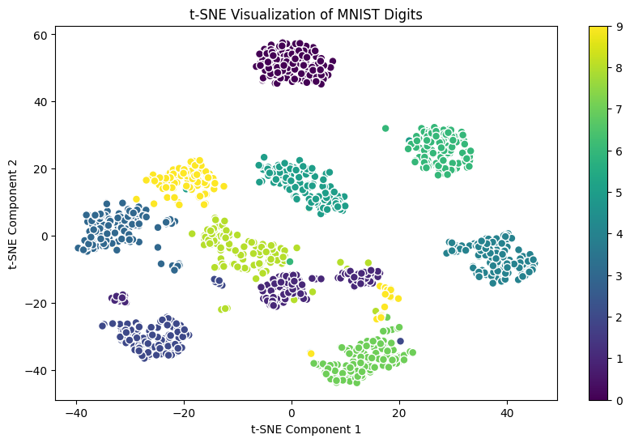

```python
from sklearn.manifold import TSNE

# Reduce dimensionality with t-SNE
tsne = TSNE(n_components=2, random_state=42)
x_tsne = tsne.fit_transform(x_train)

# Plot t-SNE result
plt.figure(figsize=(10, 6))
plt.scatter(x_tsne[:, 0], x_tsne[:, 1], c=y_train, cmap='viridis', marker='o', edgecolors='w', s=50)
plt.title('t-SNE Visualization of MNIST Digits')
plt.xlabel('t-SNE Component 1')
plt.ylabel('t-SNE Component 2')
plt.colorbar()
plt.show()
```

t-SNE는 고차원 데이터의 국소적인 구조를 보존하여 저차원(주로 2D)에 투영하는 방법으로, 데이터의 군집을 시각적으로 파악하는 데 도움이 됩니다. 하지만, 전체 데이터셋을 처리하기에는 계산 비용이 높을 수 있습니다. e데이터가 그렇게 크지 않아 사용

t-SNE로 얻은 시각화 결과를 통해 1과 8이 모델에 의해 혼돈되는 이유를 정확하게 알기는 어렵습니다. t-SNE는 데이터의 군집 구조를 보존하며 저차원으로 투영하지만, 해당 차원에서의 거리가 반드시 원본 데이터의 거리와 일치하지는 않습니다. 또한, t-SNE는 확률적이기 때문에 여러 번 실행하면 결과가 약간씩 다를 수 있습니다.

하지만, 1과 8이 모델에서 혼동되는 이유는 이미지의 구조적 유사성 때문일 가능성이 높습니다. 1과 8은 세로 선의 위치와 방향이 유사하므로, 모델이 숫자를 판별할 때 이러한 유사성으로 혼동이 발생할 수 있습니다.

추가적인 분석을 위해 다음 단계를 고려할 수 있습니다:

Misclassification Examples 확인: 1과 8 중에서 모델이 잘못 분류한 특정 예제들을 살펴보세요. 이를 통해 모델이 어떤 이미지에서 혼동을 일으키는지 확인할 수 있습니다.

픽셀 수준의 차이: 특히 1과 8의 픽셀 수준의 차이를 살펴보세요. 두 숫자 간의 주요 차이점을 이해하는 것이 도움이 될 수 있습니다.

더 나은 시각화 기법 사용: 다른 시각화 기법이나 분석 도구를 사용하여 데이터의 패턴을 더 자세히 살펴볼 수 있습니다.

또한, 모델을 조정하거나 다른 모델을 사용하여 이러한 혼동을 줄이기 위한 시도를 할 수 있습니다.

# Linear discriminant analysis

```python
from sklearn.model_selection import train_test_split
from sklearn.discriminant_analysis import LinearDiscriminantAnalysis
from sklearn.metrics import accuracy_score
from sklearn import datasets

# Load the digits dataset

digits.data, digits.target = shuffle(digits.data, digits.target, random_state=42)
x_data = digits.data
y_data = digits.target

x_train, x_test, y_train, y_test = train_test_split(x_data, y_data, test_size=0.3, random_state=42)

# Create a Linear Discriminant Analysis model
model = LinearDiscriminantAnalysis()

# Train the model
model.fit(x_train, y_train)

# Make predictions on the training set
y_train_predict = model.predict(x_train)
train_accuracy = accuracy_score(y_train, y_train_predict)
print(f'Training Accuracy: {train_accuracy}')

# Make predictions on the test set
y_test_predict = model.predict(x_test)
test_accuracy = accuracy_score(y_test, y_test_predict)
print(f'Test Accuracy: {test_accuracy}')
```

```
Training Accuracy: 0.9665871121718377
Test Accuracy: 0.9592592592592593
```

# SVC

```python
from sklearn.model_selection import train_test_split
from sklearn.svm import SVC
from sklearn.metrics import accuracy_score
from PIL import Image
import numpy as np

digits.data, digits.target = shuffle(digits.data, digits.target, random_state=42)
x_data = digits.data
y_data = digits.target

x_train, x_test, y_train, y_test = train_test_split(x_data, y_data, test_size=0.3, random_state=42)

model = SVC(kernel='linear', C=0.001) #linear SVM
#model = SVC(kernel='poly', C=0.00001, gamma='auto') #polynomial SVM
#model = SVC(kernel='rbf', C=0.6, gamma=0.001) #rbf SVM #디폴트

model.fit(x_train, y_train)

y_train_predict = model.predict(x_train)
train_accuracy = accuracy_score(y_train, y_train_predict)
print(f'Training Accuracy: {train_accuracy}')

# Make predictions on the test set
y_test_predict = model.predict(x_test)
test_accuracy = accuracy_score(y_test, y_test_predict)
print(f'Test Accuracy: {test_accuracy}')
```

[output not shown]

```python
from sklearn.model_selection import train_test_split
from sklearn.svm import SVC
from sklearn.metrics import accuracy_score
from PIL import Image
import numpy as np

digits.data, digits.target = shuffle(digits.data, digits.target, random_state=42)
x_data = digits.data
y_data = digits.target

x_train, x_test, y_train, y_test = train_test_split(x_data, y_data, test_size=0.3, random_state=42)

#estimator = SVC(kernel='linear', C=1.0) #linear SVM
model = SVC(kernel='poly', C=1.0, gamma='auto') #polynomial SVM
#model = SVC(kernel='rbf', C=0.6, gamma=0.001) #rbf SVM #디폴트
model.fit(x_train, y_train)

y_train_predict = model.predict(x_train)
train_accuracy = accuracy_score(y_train, y_train_predict)
print(f'Training Accuracy: {train_accuracy}')

# Make predictions on the test set
y_test_predict = model.predict(x_test)
test_accuracy = accuracy_score(y_test, y_test_predict)
print(f'Test Accuracy: {test_accuracy}')
```

[output not shown]

```
Training Accuracy: 0.9992044550517104
Test Accuracy: 0.9796296296296296
```

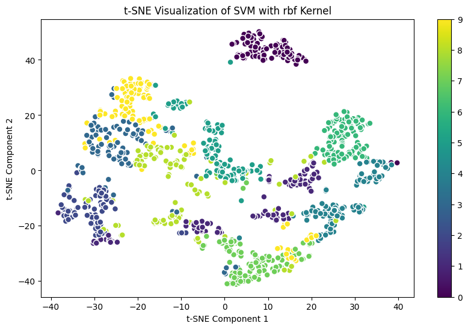

```python
from sklearn.manifold import TSNE
from sklearn.model_selection import train_test_split
from sklearn.svm import SVC
from sklearn.metrics import accuracy_score
from PIL import Image
import numpy as np

digits.data, digits.target = shuffle(digits.data, digits.target, random_state=42)
x_data = digits.data
y_data = digits.target

x_train, x_test, y_train, y_test = train_test_split(x_data, y_data, test_size=0.3, random_state=42)

#estimator = SVC(kernel='linear', C=1.0) #linear SVM
#estimator = SVC(kernel='poly', C=1.0, gamma='auto') #polynomial SVM
model = SVC(kernel='rbf', C=0.6, gamma=0.001) #rbf SVM #디폴트

model.fit(x_train, y_train)

y_train_predict = model.predict(x_train)
train_accuracy = accuracy_score(y_train, y_train_predict)
print(f'Training Accuracy: {train_accuracy}')

# Make predictions on the test set
y_test_predict = model.predict(x_test)
test_accuracy = accuracy_score(y_test, y_test_predict)
print(f'Test Accuracy: {test_accuracy}')

# Obtain decision scores for each class
decision_scores = model.decision_function(x_train)

# Reduce dimensionality with t-SNE
tsne = TSNE(n_components=2, random_state=42)
x_tsne_rbf = tsne.fit_transform(decision_scores)

# Plot t-SNE result
plt.figure(figsize=(10, 6))
plt.scatter(x_tsne_rbf[:, 0], x_tsne_rbf[:, 1], c=y_train, cmap='viridis', marker='o', edgecolors='w', s=50)
plt.title('t-SNE Visualization of SVM with rbf Kernel')
plt.xlabel('t-SNE Component 1')
plt.ylabel('t-SNE Component 2')
plt.colorbar()
plt.show()
```

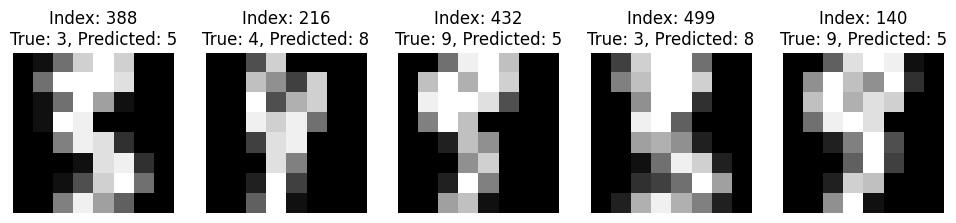

```python
import numpy as np
import matplotlib.pyplot as plt

# Make predictions on the test set
y_test_predict = model.predict(x_test)

# Find indices of misclassified samples
misclassified_indices = np.where(y_test != y_test_predict)[0]

# Select a few random misclassified samples
random_misclassified_indices = np.random.choice(misclassified_indices, size=5, replace=False)

# Plot the misclassified samples with index information
plt.figure(figsize=(12, 4))
for i, idx in enumerate(random_misclassified_indices, 1):
    plt.subplot(1, 5, i)
    plt.imshow(x_test[idx].reshape(8, 8), cmap='gray')
    plt.title(f'Index: {idx}\nTrue: {y_test[idx]}, Predicted: {y_test_predict[idx]}')
    plt.axis('off')

plt.show()
```

# multilayer perceptron

```python
import time

# 셀의 시작 부분에 다음 코드를 추가
start_time = time.time()

from sklearn.model_selection import train_test_split
from sklearn.neural_network import MLPClassifier
from sklearn.metrics import accuracy_score
from sklearn import datasets
from sklearn.preprocessing import StandardScaler

# Load the digits dataset
digits = datasets.load_digits()
digits.data, digits.target = shuffle(digits.data, digits.target, random_state=42)
x_data = digits.data
y_data = digits.target

x_train, x_test, y_train, y_test = train_test_split(x_data, y_data, test_size=0.3, random_state=42)

# Standardize the features
scaler = StandardScaler()
x_train = scaler.fit_transform(x_train)
x_test = scaler.transform(x_test)

# Create an MLP Classifier
model = MLPClassifier(hidden_layer_sizes=(100,), max_iter=90, random_state=42)

# Train the model
model.fit(x_train, y_train)

# Make predictions on the training set
y_train_predict = model.predict(x_train)
train_accuracy = accuracy_score(y_train, y_train_predict)
print(f'Training Accuracy: {train_accuracy}')

# Make predictions on the test set
y_test_predict = model.predict(x_test)
test_accuracy = accuracy_score(y_test, y_test_predict)
print(f'Test Accuracy: {test_accuracy}')

# 끝부분에
end_time = time.time()
elapsed_time = end_time - start_time
print(f"'Logistic Regresstion' Elapsed Time: {elapsed_time:.5f} seconds")
```

```
Training Accuracy: 0.9992044550517104
Test Accuracy: 0.9777777777777777
'Logistic Regresstion' Elapsed Time: 0.40317 seconds
```

# CNN

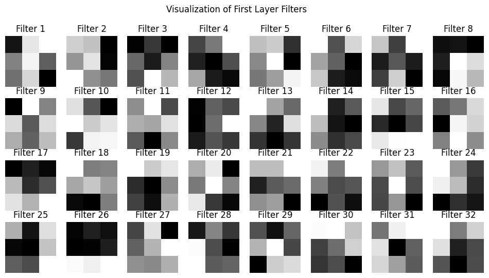

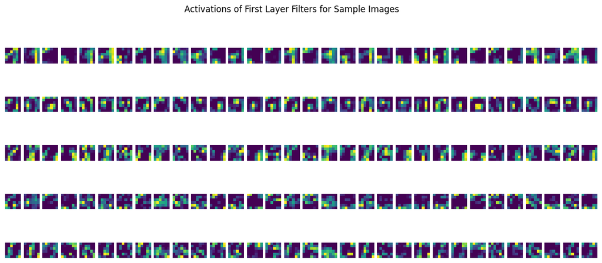

```python
import numpy as np
import matplotlib.pyplot as plt
from tensorflow.keras.models import Sequential
from tensorflow.keras.layers import Conv2D, MaxPooling2D, Flatten, Dense
from tensorflow.keras.utils import to_categorical

# Reshape data for CNN
x_train_cnn = x_train.reshape(-1, 8, 8, 1)
x_test_cnn = x_test.reshape(-1, 8, 8, 1)

# One-hot encode labels
y_train_categorical = to_categorical(y_train)
y_test_categorical = to_categorical(y_test)

# Build a simple CNN model
model_cnn = Sequential()
model_cnn.add(Conv2D(32, kernel_size=(3, 3), activation='relu', input_shape=(8, 8, 1)))
model_cnn.add(MaxPooling2D(pool_size=(2, 2)))
model_cnn.add(Flatten())
model_cnn.add(Dense(128, activation='relu'))
model_cnn.add(Dense(10, activation='softmax'))

# Compile the model
model_cnn.compile(optimizer='adam', loss='categorical_crossentropy', metrics=['accuracy'])

# Train the model
model_cnn.fit(x_train_cnn, y_train_categorical, epochs=22, batch_size=64, validation_split=0.1)

# Visualize the first layer filters
first_layer_weights = model_cnn.layers[0].get_weights()[0][:, :, 0, :]
# Visualize the first layer filters along with input patterns that activate them
plt.figure(figsize=(12, 6))

for i in range(32):
    plt.subplot(4, 8, i + 1)

    # Filter weights
    filter_weights = first_layer_weights[:, :, i]

    # Normalize filter weights to range [0, 1] for better visualization
    normalized_weights = (filter_weights - np.min(filter_weights)) / (np.max(filter_weights) - np.min(filter_weights))

    # Plot the filter weights
    plt.imshow(normalized_weights, cmap='gray')
    plt.title(f'Filter {i + 1}')
    plt.axis('off')

plt.suptitle('Visualization of First Layer Filters')
plt.show()


# Extract activations from the first layer
layer_outputs = [layer.output for layer in model_cnn.layers[:2]]  # Extract activations from the first two layers
activation_model = Model(inputs=model_cnn.input, outputs=layer_outputs)
activations = activation_model.predict(x_train_cnn[:5])  # Use the first 5 samples for visualization

plt.figure(figsize=(15, 6))
for i in range(5):  # Number of sample images
    for j in range(32):  # Number of filters in the first layer
        plt.subplot(5, 32, i * 32 + j + 1)
        plt.imshow(activations[0][i, :, :, j], cmap='viridis')
        plt.axis('off')

plt.suptitle('Activations of First Layer Filters for Sample Images')
plt.show()
```